# Apple Stock Price Data Exploration

### Milestone 3A

#### Angela Jiang, Alexander Lin, Jason Shen

### Planning it out

We were deciding between two different methods of grabbing the stock data.

1. via API calls from [Quandl](https://www.quandl.com/docs/api)
2. via direct CSV download from NASDAQ

We decided on the second because it would be simpler for the purposes of the project.

For initial exploration of data we thought about some of the aspects of the data that we would be interested in seeing. The data gives us a couple of metrics to work with:

- Close - The price of the stock at the end of the trading day.
- Open - The price of the stock at the beginning of the trading day.
- Volume - The number of shares that were traded that day
- High - The peak price of the stock for that day
- Low - The lowest price of the stock for that day

What sort of relationships between these metrics did we want to see?

1. We can look at how a given metric can change over different windows/intervals of time. For example, how the closing price changed over the course of the last month versus the change over the last year.
2. Which metrics are more meaningful?

   We're not really sure yet, so we should probably have a function that takes in the metric as a parameter and graphs accordingly.
3. We may want to see how two or more metrics may or may not correlate with one another

   Ex: Does volume of trade have a relationship with the closing price of the day?

   We may want to be able to plot more than one metric on a single graph to be able to look at these relationships.

We created functions that would allow us to generate these relationships with greater ease.

- filter_data_by_date
  - Allows us to choose the time interval we want to look at and filters the data to match this interval
- plot_stock_data
  - Function that lets us be flexible and plots the metric of our choosing.
  - Currently only plots one graph at a time
  - Allowed the option to graph the linear regression line on top of the data.

### Basic Exploration

After importing our CSV and arbitrarily choosing **closing price** to be our metric for exploration --

1. We started graphing out the data points over different intervals of time.
2. We ran some simple linear regressions for each time interval and subsequently graphed those as well.

For time intervals, we chose to explore the closing prices over the intervals of

- 10 years
- 1 year
- 6 months
- 1 month

We then peformed linear regression and plotted them on all of these to get a better visual sense of how well a linear model might fit.

Lastly we did some visualization of basic inter-metric relationship by plotting both the high and low prices of the stock price over a 10 year period. It was kind of hard to make any real sense out of the plot, since the values are so close to eachother. The only thing the graph really lets you see are weird anamolies in the data like the one in mid 2015 where the low price took a sharp dip.

```python
import numpy as np
import pandas as pd
import matplotlib
import matplotlib.pyplot as plt
from sklearn import linear_model
import nltk
nltk.download("stopwords")
from nltk.corpus import stopwords
from datetime import timedelta
from sklearn.linear_model import LogisticRegression as LogReg
from sklearn.linear_model import LogisticRegressionCV as LogRegCV
import math
import string
from six.moves.html_parser import HTMLParser
import urllib2
import json
import time
from functools import wraps
%matplotlib inline
```

```python
aapl_data = pd.read_csv('AAPL.csv', parse_dates = [0], keep_date_col = True)
aapl_data.head(n=5)
```

|  | date | close | volume | open | high | low |
| --- | --- | --- | --- | --- | --- | --- |
| 0 | 2016-11-04 | 108.84 | 30790930.0 | 108.53 | 110.25 | 108.11 |
| 1 | 2016-11-03 | 109.83 | 26538700.0 | 110.98 | 111.46 | 109.55 |
| 2 | 2016-11-02 | 111.59 | 28174980.0 | 111.40 | 112.35 | 111.23 |
| 3 | 2016-11-01 | 111.49 | 43403760.0 | 113.46 | 113.77 | 110.53 |
| 4 | 2016-10-31 | 113.54 | 26378910.0 | 113.65 | 114.23 | 113.20 |

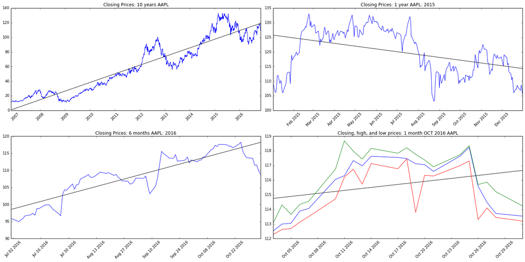

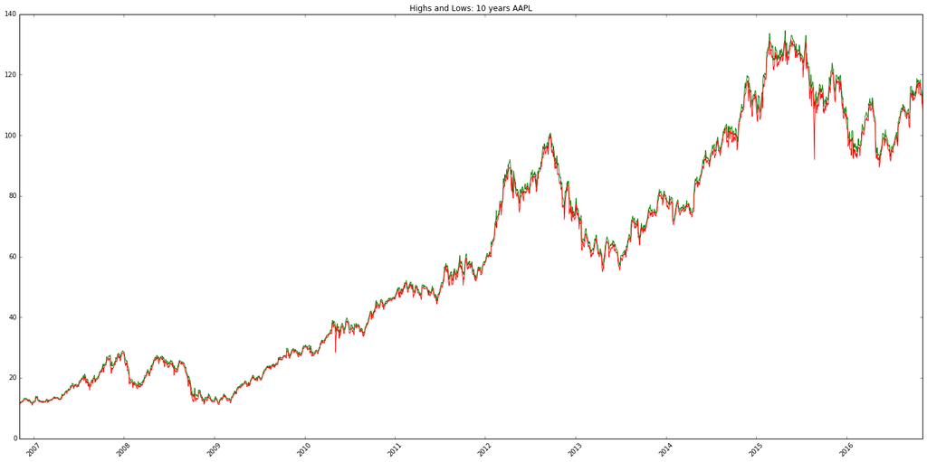

```python
""" Function that filters stock data according to the input start and end dates (inclusive)
    Input and output data are pandas dataframes """
def filter_data_by_date(data, date_start, date_end):
    return data[(data['date'] >= date_start) & (data['date'] <= date_end)]

""" Function plots graph of data
        data: a dataframe
        ax: axis to be plotted on
        option: 'close' (default), 'volume', 'open', 'high', or 'low'
        title: title of the plot (string)
        lin_reg: whether to fit and plot LR line
        color: color of line """
def plot_stock_data(data, ax, option="close", title="", lin_reg=False, color='b'):
    ax.set_title(title)
    ax.plot(data['date'].values, data[option].values, c=color)

    if(lin_reg):
        lin_reg = linear_model.LinearRegression()
        x_vals = np.arange(len(data['date'].values)).reshape(len(data['date'].values),1)
        lin_reg.fit(x_vals, data[option].values)
        y = lin_reg.predict([[0],[len(data['date'].values)-1]])
        ax.plot([data['date'].values[0], data['date'].values[len(data['date'].values)-1]], y, c='black')

    for tick in ax.get_xticklabels():
        tick.set_rotation(45)

    return ax

fig, ax = plt.subplots(2, 2, figsize=(20, 10))
plot_stock_data(aapl_data, ax[0][0], title="Closing Prices: 10 years AAPL", lin_reg=True)
plot_stock_data(filter_data_by_date(aapl_data,'2015-1-1', '2015-12-31'), ax[0][1], title="Closing Prices: 1 year AAPL: 2015", lin_reg=True)
plot_stock_data(filter_data_by_date(aapl_data,'2016-7-1', '2016-12-31'), ax[1][0], title="Closing Prices: 6 months AAPL: 2016", lin_reg=True)
plot_stock_data(filter_data_by_date(aapl_data,'2016-10-1', '2016-10-31'), ax[1][1], title="Closing Prices: 1 month OCT 2016 AAPL", lin_reg=True)
plot_stock_data(filter_data_by_date(aapl_data,'2016-10-1', '2016-10-31'), ax[1][1], option='high', title="Closing Prices: 1 month OCT 2016 AAPL", color='g')
plot_stock_data(filter_data_by_date(aapl_data,'2016-10-1', '2016-10-31'), ax[1][1], option='low', title="Closing, high, and low prices: 1 month OCT 2016 AAPL", color='r')
plt.tight_layout()
plt.show()

fig, ax = plt.subplots(1, 1, figsize=(20, 10))
plot_stock_data(aapl_data, ax, option='high', title="Highs and Lows: 10 years AAPL", color='g')
plot_stock_data(aapl_data, ax, option='low', title="Highs and Lows: 10 years AAPL", color='r')
plt.tight_layout()
plt.show()
```

### Next steps

- We looked at potential sources for news data. It turns out that the API we wanted to use (www.newsapi.com) does not allow us to access historical news articles and only what was most recently published. We tried looking at other sources, and here is what we found:

-- Bloomberg API seems to be geared more torwards financial data than data from Bloomberg News.

-- Google News API has depreciated, but there is a Bing API that allows for News Search. We decided that it would be too broad for our purposes, since we are going to currently restrict our model to working with one news source.

-- Other, smaller news outlets that are technology oriented do not really have APIs.

```python
def retry(ExceptionToCheck, tries=4, delay=3, backoff=2, logger=None):
    """Retry calling the decorated function using an exponential backoff.

    http://www.saltycrane.com/blog/2009/11/trying-out-retry-decorator-python/
    original from: http://wiki.python.org/moin/PythonDecoratorLibrary#Retry

    :param ExceptionToCheck: the exception to check. may be a tuple of
        exceptions to check
    :type ExceptionToCheck: Exception or tuple
    :param tries: number of times to try (not retry) before giving up
    :type tries: int
    :param delay: initial delay between retries in seconds
    :type delay: int
    :param backoff: backoff multiplier e.g. value of 2 will double the delay
        each retry
    :type backoff: int
    :param logger: logger to use. If None, print
    :type logger: logging.Logger instance
    """
    def deco_retry(f):

        @wraps(f)
        def f_retry(*args, **kwargs):
            mtries, mdelay = tries, delay
            while mtries > 1:
                try:
                    return f(*args, **kwargs)
                except ExceptionToCheck, e:
                    msg = "%s, Retrying in %d seconds..." % (str(e), mdelay)
                    if logger:
                        logger.warning(msg)
                    else:
                        print msg
                    time.sleep(mdelay)
                    mtries -= 1
                    mdelay *= backoff
            return f(*args, **kwargs)

        return f_retry  # true decorator

    return deco_retry

@retry(urllib2.HTTPError, tries=4, delay=3, backoff=2)
def get_url_with_retry(url):
    response = urllib2.urlopen(url)
    text = response.read()
    test = json.loads(text)
    response.close()
    return test

def make_url(year, month, api_key):
    return 'http://api.nytimes.com/svc/archive/v1/{}/{}.json?api-key={}'.format(year, month, api_key)

def get_news_by_time(df, year, month, api_key):
    df_index = df.shape[0]

    # set URL with parameters of year and month [earliest first]
    url = make_url(year, month, api_key)
    # initial API call
    returned = get_url_with_retry(url)

    # get num results
    num_results = len(returned['response']['docs'])
    print 'Number of total results for {}/{}: {}'.format(month, year, num_results)

    articles_month_count = 0

    # for each of the results of the month, add results to dataframe
    for i, result in enumerate(returned['response']['docs']):
        # only look at articles, not multimedia or blog posts
        if type(result) is tuple:
            print i, result
            result = result[1]
        if result['document_type'] == 'article':
            if 'main' in result['headline']:
                headline = result['headline']['main']
            else:
                headline = result['lead_paragraph']
            df.loc[df_index] = [headline, result['lead_paragraph'], result['pub_date']]
            df_index += 1
            articles_month_count += 1

    print 'Number of article results for {}/{}: {}'.format(month, year, articles_month_count)

    return df
```

```python
ten_year_data = pd.DataFrame(columns=('headline', 'paragraph', 'pub_date'))
```

```python
api_key = 'd5a1e6fab7f04a10b2d3844b1b32b1ba'
start_year = 2014
start_month = 2
end_year = 2016
end_month = 11
```

```python
num_calls = (end_year - start_year)*12 + end_month  - start_month + 1
year = start_year
month = start_month

for call in range(num_calls):
    ten_year_data = get_news_by_time(ten_year_data, year, month, 'd5a1e6fab7f04a10b2d3844b1b32b1ba')

    # to next month
    month += 1
    if month == 13:
        month = 1
        year += 1
```

```
Number of total results for 2/2014: 7742
Number of article results for 2/2014: 4767
Number of total results for 3/2014: 8088
Number of article results for 3/2014: 5345
Number of total results for 4/2014: 7765
Number of article results for 4/2014: 5168
Number of total results for 5/2014: 8026
Number of article results for 5/2014: 5525
Number of total results for 6/2014: 8157
Number of article results for 6/2014: 5389
Number of total results for 7/2014: 7405
Number of article results for 7/2014: 5022
Number of total results for 8/2014: 7080
Number of article results for 8/2014: 4858
Number of total results for 9/2014: 8212
Number of article results for 9/2014: 5162
Number of total results for 10/2014: 8403
Number of article results for 10/2014: 5437
Number of total results for 11/2014: 7566
Number of article results for 11/2014: 5223
Number of total results for 12/2014: 7375
Number of article results for 12/2014: 4934
Number of total results for 1/2015: 7207
Number of article results for 1/2015: 4870
Number of total results for 2/2015: 6768
Number of article results for 2/2015: 4477
Number of total results for 3/2015: 7078
Number of article results for 3/2015: 5116
Number of total results for 4/2015: 7016
Number of article results for 4/2015: 5070
Number of total results for 5/2015: 7260
Number of article results for 5/2015: 5366
Number of total results for 6/2015: 7146
Number of article results for 6/2015: 5058
Number of total results for 7/2015: 7101
Number of article results for 7/2015: 5049
Number of total results for 8/2015: 6682
Number of article results for 8/2015: 4764
Number of total results for 9/2015: 7575
```

[output not shown]

[output cut: 18 more lines]

[output not shown]

```python
ten_year_data[-1:]
```

|  | headline | paragraph | pub_date |
| --- | --- | --- | --- |
| 590477 | Siri, Apple Music and Other iPhone Questions | We asked readers to send us questions about Ap... | 2015-09-23T00:00:00Z |

```python
ten_year_data.shape
```

```
(590478, 3)
```

```python
data_to_9_2015 = ten_year_data.reset_index(drop=True)
data_to_9_2015.head(n=5)
data_to_9_2015.to_excel('data_to_9_2015_2.xlsx')
```

```python
df = pd.read_csv('10_years_data.csv', parse_dates = [2], keep_date_col = True, encoding = 'cp1252')
print 'Number of total articles:', df.shape[0]

""" data = pandas dataframe with columns 'pub_date', 'headline', 'paragraph'
    option = 'title' or 'abstract' (default = 'title')
    date_filer = (start date, end date) inclusive; else if default = None, then no filter
    word_filter = list of words to filter OPTION by (CASE SENSITIVE); default is None """
def filter_data(data, option = 'title', date_filter = None, word_filter = None):
    h = HTMLParser()

    # filter by dates
    if date_filter is not None:
        start_date, end_date = date_filter
        filtered_data = data[(data['publish_date'] >= start_date) & (data['publish_date'] <= end_date)]
    else:
        filtered_data = data

    # filter by words
    if word_filter is not None:
        idx_to_drop = [] # store indices of rows that do not contain filter words

        # for every article
        for i in range(filtered_data.shape[0]):
            text = filtered_data.iloc[i][option]
            # iterates through each filter word
            filter_flag = 0
            # if there is no text (type is not string)
            if isinstance(text, basestring) is False:
                idx_to_drop.append(i)
                continue
            for word in word_filter:
                if word in text:
                    filter_flag = 1
                    break
            if filter_flag == 0:
                idx_to_drop.append(i)

    # drops rows without words in filter
    filtered_data = filtered_data.drop(filtered_data.index[idx_to_drop])

    # remove capitalization
    filtered_data[option] = filtered_data[option].str.lower()

    # remove punctuation
    # remove html encoding puncuation from old news
    html_encoding = ['&#8217;', '&#8212;', '&#038;', '&#8230;', '&#8220;', '&#8221;']
    for i in range(filtered_data.shape[0]):
        for encoding in html_encoding:
            if encoding in filtered_data.iloc[i][option]:
                index = filtered_data.index[i]
                filtered_data.loc[index, option] = filtered_data.loc[index, option].replace(encoding, h.unescape(encoding))

    # remove other punctuation
    punctuation = list(',.!@#$%^&*()\'\"`:;?' + u'\u2018' + u'\u2019')
    for c in punctuation:
        filtered_data[option] = filtered_data[option].str.replace(c, '')

    # remove stop words
    for i in range(filtered_data.shape[0]):
        headline = filtered_data.iloc[i][option]
        headline = headline.split()
        new_headline = []
        for word in headline:
            if word not in stopwords.words('english'):
                new_headline += [word]

        index = filtered_data.index[i]
        filtered_data.loc[index, option] = ' '.join(new_headline)

    return filtered_data

# makes bag of words given a pre-filtered DF and the option of using title or abstract
def make_bag_of_words(df, option = 'title'):
    num_articles = df.shape[0]
    words_lst = []
    for i in range(num_articles):
        words_lst += df.iloc[i][option].split()

    unique_words = list(set(words_lst))
    print '\nNumber of unique words across all text (including stopwords):', len(unique_words)

    # new predictors
    bag_words = np.zeros((df.shape[0], len(unique_words)))

    # text of words is a list
    for i in range(num_articles):
        text = df.iloc[i][option].split()
        for word in text:
            word_col_num = unique_words.index(word)
            bag_words[i, word_col_num] += 1

    print unique_words[:20]
    print bag_words[:5, :20]

    return bag_words, unique_words
```

[output not shown]

```python
filtered_df = filter_data(df, word_filter = ['Apple', 'AAPL', 'iPhone', 'iPod', 'Mac', 'MacBook'], option = 'headline')
print 'Number of articles after filtering:', filtered_df.shape[0]
bag_words, unique_words = make_bag_of_words(filtered_df, option = 'headline')
```

```python
# Number of Top words to Look At
num_top_words = 50

# Count the number of time each word occurs in the entire dataset
word_freq = bag_words.sum(axis=0)
print word_freq.shape

words = zip(word_freq, unique_words)
top_words = (sorted(words, key=lambda t: t[0], reverse=True))[:num_top_words]

print top_words
```

```
(1698,)
[(140.0, u'apple'), (83.0, u'iphone'), (54.0, u'apples'), (25.0, u'new'), (25.0, u'software'), (17.0, u'iphones'), (17.0, u'company'), (16.0, u'sales'), (14.0, u'may'), (14.0, u'one'), (14.0, u'jobs'), (14.0, u'google'), (13.0, u'like'), (12.0, u'tech'), (12.0, u'said'), (12.0, u'products'), (12.0, …
```

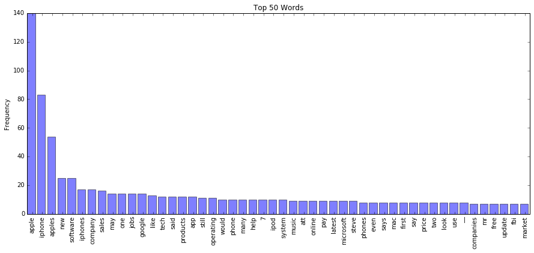

```python
fig, ax = plt.subplots(1, 1, figsize=(15, 6))

#Number of bars to use
indices = np.arange(num_top_words)
#Where to put the label under each bar
width = 0.5
#Bar plot of the frequencies of the top words
ax.bar(indices, [word[0] for word in top_words], color='blue', alpha=0.5)

ax.set_ylabel('Frequency')
ax.set_title('Top ' + str(num_top_words) + ' Words')

#Label the bars with the top words
ax.set_xticks(indices + width)
ax.set_xticklabels([word[1] for word in top_words])

#Turn the labels sideways so they don't overlap
labels = ax.get_xticklabels()
plt.setp(labels, rotation=90, fontsize=10)

plt.show()
```

```python
filtered_df[-1:]
```

|  | title | abstract | publish_date |
| --- | --- | --- | --- |
| 4705 | Macworld Rumors | hottest rumors revolving around upcoming macwo... | 2007-01-04 |

```python
stock_price = pd.read_csv('12-4-06-to-12-3-16-Quotes.csv', parse_dates = [0], keep_date_col = True, encoding = 'cp1252')

stock_price.head(n=5)
```

|  | date | close | volume | open | high | low |
| --- | --- | --- | --- | --- | --- | --- |
| 0 | 2016-12-02 | 109.90 | 26481320.0 | 109.170 | 110.090 | 108.85 |
| 1 | 2016-12-01 | 109.49 | 37034520.0 | 110.365 | 110.940 | 109.03 |
| 2 | 2016-11-30 | 110.52 | 36151450.0 | 111.600 | 112.200 | 110.27 |
| 3 | 2016-11-29 | 111.46 | 28507780.0 | 110.780 | 112.030 | 110.07 |
| 4 | 2016-11-28 | 111.57 | 27054320.0 | 111.430 | 112.465 | 111.39 |

```python
""" Function returns the nearest date closest to the given date
        stock_df: a dataframe
        date: a date in date format
        time_type: "before" or "after"
            "before": finds the nearest business day before the given date
            "after": finds the nearest business day after the given date """
def find_nearest_biz_day(stock_df, date, time_type):
    price = stock_df[stock_df['date'] == date]['close'].values
    if time_type == 'after':
        # if date exists (i.e., not weekend or holiday)
        if price.size != 0:
            return date
        # if weekend or holiday
        else:
            new_date = date + timedelta(days = 1)
            return find_nearest_biz_day(stock_df, date + timedelta(days = 1), 'after')
    elif time_type == 'before' or time_type == 'before and done':
        day_before_price = stock_df[stock_df['date'] == date - timedelta(days = 1)]['close'].values
        # if date exists (i.e., not weekend or holiday)
        if price.size != 0 and day_before_price != 0 and time_type == 'before':
            return date - timedelta(days = 1)
        elif price.size != 0 and time_type == 'before and done':
            return date
        # if weekend or holiday
        else:
            return find_nearest_biz_day(stock_df, date - timedelta(days = 1), 'before and done')
```

```python
results = []
before_p = []
after_p = []
price_list = []

# iterate through news article's weekday along with corresponding published date
for date in filtered_df['publish_date']:
    compare_date_after = find_nearest_biz_day(stock_price, date, 'after')
    compare_date_before = find_nearest_biz_day(stock_price, date, 'before')
    price_after = stock_price[stock_price['date'] == compare_date_after]['close'].values
    price_before = stock_price[stock_price['date'] == compare_date_before]['close'].values

    # stock price the day after is higher than stock price day before, encode binary 1
    if price_after[0] > price_before[0]:
        results += [1]
    # no increase or decrease in stock price, encode binary 0
    else:
        results += [0]

    # true before and after values
    before_p += [price_before[0]]
    after_p += [price_after[0]]

filtered_df['price_before'] = before_p
filtered_df['price_after'] = after_p
filtered_df['y'] = results
```

```python
train_size = .25

x_train = bag_words[:int(math.ceil(train_size*len(bag_words)))]
y_train = filtered_df['y'].values[:int(math.ceil(train_size*len(bag_words)))]

x_test = bag_words[int(math.ceil(train_size*len(bag_words))):]
y_test = filtered_df['y'].values[int(math.ceil(train_size*len(bag_words))):]

ones_test = np.count_nonzero(y_test)
zeros_test = len(y_test) - ones_test
ones_train = np.count_nonzero(y_train)
zeros_train = len(y_train) - ones_train

print 'Ones Count - Train: ', ones_train
print 'Zeros Count - Train: ', zeros_train
print 'Ones Count - Test: ', ones_test
print 'Zeros Count - Test: ', zeros_test
```

```
Ones Count - Train:  30
Zeros Count - Train:  32
Ones Count - Test:  94
Zeros Count - Test:  89
```

```python
regularization = 10.**np.arange(-10, 5)
logistic = LogRegCV(cv=5,
                    penalty='l2',
                    Cs=regularization,
                    solver='liblinear',
                    n_jobs=1)
logistic.fit(x_train, y_train)
```

```
LogisticRegressionCV(Cs=array([  1.00000e-10,   1.00000e-09,   1.00000e-08,   1.00000e-07,
         1.00000e-06,   1.00000e-05,   1.00000e-04,   1.00000e-03,
         1.00000e-02,   1.00000e-01,   1.00000e+00,   1.00000e+01,
         1.00000e+02,   1.00000e+03,   1.00000e+04]),
           class_weight=None, cv=5, dual=False, fit_intercept=True,
           intercept_scaling=1.0, max_iter=100, multi_class='ovr',
           n_jobs=1, penalty='l2', random_state=None, refit=True,
           scoring=None, solver='liblinear', tol=0.0001, verbose=0)
```

```python
logistic.score(x_test, y_test)
```

```
0.49180327868852458
```

```python
train_sizes = np.arange(0.1, 0.9, 0.025)
scores_train = np.zeros(len(train_sizes))
scores_test = np.zeros(len(train_sizes))
scores_index = 0

for i in train_sizes:

    x_train = bag_words[:int(math.ceil(i*len(bag_words)))]
    y_train = filtered_df['y'].values[:int(math.ceil(i*len(bag_words)))]

    x_test = bag_words[int(math.ceil(i*len(bag_words))):]
    y_test = filtered_df['y'].values[int(math.ceil(i*len(bag_words))):]

    regularization = 10.**np.arange(-10, 5)
    logistic = LogRegCV(cv=5,
                        penalty='l2',
                        Cs=regularization,
                        solver='liblinear',
                        n_jobs=1)
    logistic.fit(x_train, y_train)

    scores_test[scores_index] = logistic.score(x_test, y_test)
    scores_train[scores_index] = logistic.score(x_train, y_train)
    scores_index += 1
```

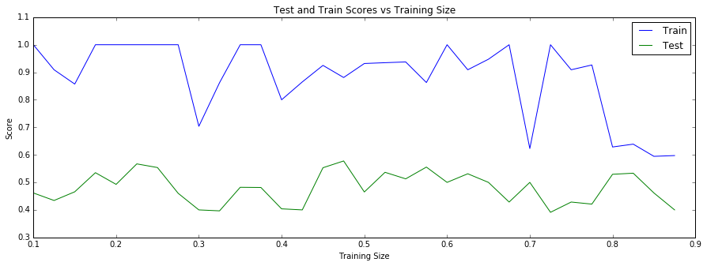

```python
fig, ax = plt.subplots(1, 1, figsize=(15, 5))

ax.plot(train_sizes, scores_train, label='Train')
ax.plot(train_sizes, scores_test, label='Test')

ax.set_xlabel('Training Size')

ax.set_ylabel('Score')
ax.set_ylim(0.3,1.1)
ax.set_title('Test and Train Scores vs Training Size')

#Turn the labels sideways so they don't overlap
plt.setp(labels, rotation=90, fontsize=10)
plt.legend()
plt.show()
```

```python
filtered_df[-100:]
```

|  | title | abstract | publish_date | price_before | price_after | y |
| --- | --- | --- | --- | --- | --- | --- |
| 3811 | Daily Report: In Return to Twitter, Jack Dors... | steve jobs returned apple saved company remain... | 2015-06-17 | 127.6000 | 127.3000 | 0 |
| 3928 | Q&A: Moving Playlists to the iPod in iTunes 11 | apples new itunes 11 program may look differen... | 2012-12-14 | 75.6700 | 72.8277 | 0 |
| 3929 | Larry Page on Regulation, Maps and Google's So... | first public appearance since company said los... | 2012-10-17 | 92.8275 | 92.0876 | 0 |
| 3934 | The iPhone Economy | apples iphone model american ingenuity compone... | 2012-01-21 | 60.0428 | 61.0584 | 1 |
| 3974 | Siri Is One Funny Lady | siri personal assistant software new apple iph... | 2011-10-14 | 58.3471 | 60.2857 | 1 |
| 3993 | Bank Suits Over Mortgages Are Filed | federal regulators filed suits friday several ... | 2011-09-02 | 54.4328 | 53.4357 | 0 |
| 4064 | Who Is Really Hurt by Apple Rumor Site&#8217;s... | apple settled suit think secret site agreed cl... | 2007-12-20 | 26.1600 | 26.7443 | 1 |
| 4095 | What Should Apple Do With its Piggy Bank? | apple put additional 5 billion bank last year ... | 2007-12-07 | 27.1361 | 27.7571 | 1 |
| 4096 | Is Macrovision Bringing More Cops to Your Livi... | macrovision hopes buying tv guide let merge co... | 2007-12-07 | 27.1361 | 27.7571 | 1 |
| 4107 | The March of the iPhone Clones | verizons new 49 voyager phone one first iphone... | 2007-12-04 | 25.5514 | 25.6871 | 1 |
| 4111 | DVD Movies With an iTunes Copy: Worth More? | question day reports say apple negotiating get... | 2007-12-03 | 26.0314 | 25.5514 | 0 |
| 4121 | Don’t Give Up on Leopard (Despite the Bugs) | even apple mocks problems windows vista os x l... | 2007-11-28 | 24.9728 | 25.7457 | 1 |
| 4130 | A Little Attack Ad for Apple | apples attack ad microsfts vista retains bemus... | 2007-11-26 | 24.5057 | 24.6488 | 1 |
| 4133 | Turning Nonworking Gizmos Into Money | entrepreneur builds business around buying bro... | 2007-11-23 | 24.0657 | 24.5057 | 1 |
| 4143 | J Allard: Dancing Around the Cellphone Question | microsoft hopes respond iphone better software... | 2007-11-16 | 23.4714 | 23.7700 | 1 |
| 4155 | A First Look at the Google Phone | google gives first look google phones based an... | 2007-11-12 | 23.6243 | 21.9657 | 0 |
| 4159 | Apple Notes: Finding Clues About Movie Rentals | search apples code unleashes fever speculation... | 2007-11-09 | 25.0666 | 23.6243 | 0 |
| 4162 | Apple Notes: Another iPhone Jailbreak | apple locks iphone hackers release | 2007-11-09 | 25.0666 | 23.6243 | 0 |
| 4180 | The GPhone: So Open It Could Be Closed | googles android software meant support cellpho... | 2007-11-05 | 26.8386 | 26.5971 | 0 |
| 4183 | One Other Little Dance | googles introduction cellphone operating syste... | 2007-11-05 | 26.8386 | 26.5971 | 0 |
| 4201 | Imeem Q&#038;A: Competing in Music Through Com... | answering questions bits readers dalton caldwe... | 2007-10-31 | 26.7143 | 27.1357 | 1 |
| 4212 | A One-Click iPhone Jailbreak | hacker group released says one-click way insta... | 2007-10-29 | 26.3857 | 26.4414 | 1 |
| 4214 | The $831 iPhone | gene munster analyst piper jaffray calculates ... | 2007-10-25 | 26.5614 | 26.1114 | 0 |
| 4225 | How Apple Can Keep Its Value | market value 162 billion apple valuable comput... | 2007-10-23 | 24.9086 | 26.5943 | 1 |
| 4229 | Apple: $100 Million Spent on Potential iBricks | interesting tidbit apple earnings call 14 mill... | 2007-10-22 | 24.3457 | 24.9086 | 1 |
| 4241 | Programmers Welcome for the iPhone … Next Year | steve jobs writes apple release software devel... | 2007-10-17 | 24.2257 | 24.6786 | 1 |
| 4249 | Apple Backs Down on Premium Prices for Unprote... | apple dropped price music downloads protected ... | 2007-10-16 | 23.8543 | 24.2257 | 1 |
| 4269 | Lawyer Sues Over iPhone’s Little White List | federal suit claims apples restrictions iphone... | 2007-10-10 | 23.9800 | 23.8271 | 0 |
| 4271 | Hackers Break Out of the iPhone (but Not for L... | iphone opened unofficial applications apple ap... | 2007-10-10 | 23.9800 | 23.8271 | 0 |
| 4275 | What GPhone? | google getting phone software business competi... | 2007-10-08 | 23.0643 | 23.9871 | 1 |
| ... | ... | ... | ... | ... | ... | ... |
| 4579 | How to Make a $600 iPod | hackers figure use iphone music wifi browsing ... | 2007-07-03 | 17.3229 | 18.1671 | 1 |
| 4584 | AT&#038;T Says the iPhone Is Its Best Seller Ever | att said afternoon partnership apple nations l... | 2007-07-02 | 17.4343 | 17.3229 | 0 |
| 4590 | Steve Jobs Was 2 for 3 This Weekend | hit weekend iphone pixars ratatouille little t... | 2007-07-02 | 17.4343 | 17.3229 | 0 |
| 4596 | IPhone: Waiting for Ma Bell | apple lots iphones stock att takes hours activate | 2007-06-30 | 17.4343 | 17.3229 | 0 |
| 4597 | Sad Scenes at an AT&#038;T Wireless Store | contrast party atmosphere apple stores bay are... | 2007-06-30 | 17.4343 | 17.3229 | 0 |
| 4600 | IPhone: It&#8217;s Time | latest updates iphone finally reaches hands ma... | 2007-06-29 | 17.2229 | 17.4343 | 1 |
| 4606 | Love the iPhone, buy Google? | wowed iphone buy google apple argues wall stre... | 2007-06-29 | 17.2229 | 17.4343 | 1 |
| 4608 | Dude, You&#8217;re Getting an iPhone | steve jobs promises give apple employees free ... | 2007-06-28 | 17.4129 | 17.2229 | 0 |
| 4609 | Get Two, They Last Longer | many iphones one person buy | 2007-06-28 | 17.4129 | 17.2229 | 0 |
| 4611 | Q&#038;A: Ask About iPod Pricing | authors study tries figure source cost parts g... | 2007-06-28 | 17.4129 | 17.2229 | 0 |
| 4615 | Tip: Finding That iPhone | apple trying helpful web page tell apple store... | 2007-06-28 | 17.4129 | 17.2229 | 0 |
| 4617 | Doing It First, Over and Over and Over | rituals like camping first iphone — reading — ... | 2007-06-27 | 17.0929 | 17.4129 | 1 |
| 4620 | The Reviews Are In | iphone reviews major media | 2007-06-27 | 17.0929 | 17.4129 | 1 |
| 4627 | Will the iPhone Get Cheaper? | look apples pricing strategy | 2007-06-26 | 17.4771 | 17.0929 | 0 |
| 4628 | Ecumenicalism and the iPhone | words used describe iphone reflect miraculous ... | 2007-06-26 | 17.4771 | 17.0929 | 0 |
| 4630 | Remember Macintosh? | apple make computers new leopard operating sys... | 2007-06-26 | 17.4771 | 17.0929 | 0 |
| 4659 | The Ultimate iPhone Frequently Asked Questions | apples new device prompted negative positive r... | 2007-01-11 | 13.8571 | 13.6857 | 0 |
| 4660 | The Apple of Their Eyes | judging form first bunch comments got iphone m... | 2007-01-11 | 13.8571 | 13.6857 | 0 |
| 4662 | iPhone Pros and Cons | apple doesnt booth ces clearly doesnt need one... | 2007-01-10 | 13.2243 | 13.8571 | 1 |
| 4665 | Hush Tactics for the iPhone | cingular managed keep iphone secret | 2007-01-10 | 13.2243 | 13.8571 | 1 |
| 4666 | Last Year&#8217;s Model? | apple cellphone getting attention company also... | 2007-01-10 | 13.2243 | 13.8571 | 1 |
| 4667 | More iPhone Fun Facts | cant wait buy iphone another cellular carrier ... | 2007-01-10 | 13.2243 | 13.8571 | 1 |
| 4670 | The iPhone Rumors Are Right&#8230;Finally | ok three years wrong rumor sites finally right... | 2007-01-09 | 12.2100 | 13.2243 | 1 |
| 4672 | Samsung vs. Apple | samsung thinks crack apples hold music player ... | 2007-01-09 | 12.2100 | 13.2243 | 1 |
| 4673 | Some Hands-On Time With the iPhone | things cant tell without actually handling usi... | 2007-01-09 | 12.2100 | 13.2243 | 1 |
| 4676 | Pricing the iPhone | rob glaser chief executive real networks apple... | 2007-01-09 | 12.2100 | 13.2243 | 1 |
| 4684 | Praise for Apple | john sculley former ceo apple computer may got... | 2007-01-08 | 12.1500 | 12.2100 | 1 |
| 4698 | The Macworld-C.E.S. Conflict | way escape macworld going steal thunder ces year | 2007-01-06 | 12.1500 | 12.2100 | 1 |
| 4701 | Macworld Bingo | macworld bingo watch speech apples chief steve... | 2007-01-05 | 12.2371 | 12.1500 | 0 |
| 4705 | Macworld Rumors | hottest rumors revolving around upcoming macwo... | 2007-01-04 | 11.9714 | 12.2371 | 1 |

100 rows × 6 columns

```python
years = range(2006, 2017)
for year in years:
    original_year_df = df[(df['publish_date'] >= str(year) + '-01-01') & (df['publish_date'] <= str(year) + '-12-31')]
    filtered_year_df = filtered_df[(filtered_df['publish_date'] >= str(year) + '-01-01') & (filtered_df['publish_date'] <= str(year) + '-12-31')]
    print 'Original ({}): {}'.format(year, original_year_df.shape[0])
    print 'Filtered ({}): {}'.format(year, filtered_year_df.shape[0])
```

```
Original (2006): 0
Filtered (2006): 0
Original (2007): 646
Filtered (2007): 94
Original (2008): 6
Filtered (2008): 0
Original (2009): 6
Filtered (2009): 0
Original (2010): 36
Filtered (2010): 0
Original (2011): 75
Filtered (2011): 2
Original (2012): 9
Filtered (2012): 3
Original (2013): 18
Filtered (2013): 0
Original (2014): 66
Filtered (2014): 0
Original (2015): 87
Filtered (2015): 2
Original (2016): 3757
Filtered (2016): 144
```